# PS6

## Problem 1

In the notes, we defined a C_mean function. Using this as a template, implement a C_moment function that returns the kth central moment. Generate a vector of moderate length and show that you are able to replicate the results of e1071::moment.

```r
# rm(list=ls())
library(Rcpp)
cppFunction("
double C_moment(NumericVector x,
                int order = 1) {

  double sum = 0;
  for (int i = 0; i < x.length(); ++i){
     sum += pow(x[i], order);
  }
  return(sum / x.length());
}")
```

```r
# install.packages("e1071")
library(e1071)
x <- rnorm(100)
cat("Order = 1: \nC_moment: ", C_moment(x), "\ne1071 moment: ", moment(x))
```

```
Order = 1:
C_moment:  0.1637082
e1071 moment:  0.1637082
```

```r
cat("Order = 2: \nC_moment: ", C_moment(x, order=2), "\ne1071 moment: ", moment(x, order=2))
```

```
Order = 2:
C_moment:  1.029162
e1071 moment:  1.029162
```

## Problem 2

1. Write a class bootstrapWaldCI that produces a CI using bootstrap, similar to waldCI.

```r
library(parallel)

source("data/ps6-waldci.R")

bootstrapWaldCI <- setClass("bootstrapWaldCI",
                      contains = "waldCI",
                      slots = c(f = "function",
                                data = "data.frame",
                                reps = "numeric",
                                boot = "numeric",
                                compute = "character"))

#' Bootstrap Helper Function
#'
#' @param f a function
#' @param data dataframe
#'
#' @returns the result of the bootstrap
boot <- function(f, data) {
  data <- data[sample(1:nrow(data), replace = TRUE), ]
  return(f(data))
}

#' Construct a "bootstrapWaldCI" object
#'
#' @param f a function
#' @param data dataframe
#' @param reps number of bootstrap repetitions
#' @param level confidence level
#' @param compute serial (no parallel processing) or parallel (using sockets)
#'
#' @returns "bootstrapWaldCI" object
#' @export
makeBootstrapCI <- function(f,
                            data,
                            reps = 1000,
                            level = 0.95,
                            compute = "serial") {

  boot <- 0

  if (compute == "serial") {

    boot <- sapply(seq_len(reps), function(x) boot(f, data))

  } else if (compute == "parallel") {

    # because i am on windows
    # i have to use sockets
    cl <- makeCluster(4)
    boot <- parSapply(cl, seq_len(reps), function(x) boot(f, data))
    stopCluster(cl)

  } else {
    stop("compute must be 'serial' or 'parallel'")
  }

  # fill in waldCI slots

  m <- mean(boot)
  se <- sd(boot)

  new("bootstrapWaldCI",
      level = level,
      mean  = m,
      sterr = se,
      f = f,
      data = data,
      reps = reps,
      boot = boot,
      compute = compute)
}

##' Performs a new bootstrap
##' @param object a "bootstrapWaldCI" object
##' @return a "bootstrapWaldCI" object
##' @export
setGeneric("rebootstrap", function(object) {
  standardGeneric("rebootstrap")
})
```

```
[1] "rebootstrap"
```

```r
setMethod("rebootstrap", "bootstrapWaldCI", function(object) {
  if (object@compute == "serial") {

    boot <- sapply(seq_len(object@reps), function(x) boot(object@f, object@data))

  } else if (object@compute == "parallel") {

    cl <- makeCluster(4)
    boot <- parSapply(cl, seq_len(object@reps), function(x) boot(object@f, object@data))
    stopCluster(cl)

  } else {
    stop("compute must be 'serial' or 'parallel'")
  }


  m  <- mean(boot)
  se <- sd(boot)
  z  <- qnorm(1 - (1 - object@level)/2)

  object@mean  <- m
  object@sterr <- se
  object@boot <- boot

  return(object)
  }
)
```

2. Show your code works by executing the following:

```r
ci1 <- makeBootstrapCI(function(x) mean(x$y),
                       ggplot2::diamonds,
                       reps = 1000)
ci1
```

```
95% CI: (5.725049, 5.744197)
```

```r
rebootstrap(ci1)
```

```
95% CI: (5.725044, 5.744218)
```

3. Write a function called dispCoef that takes in data (based upon mtcars; it must take in a generic data for the bootstrap) and fits the model: mpg ~ cyl + disp + wt. It should return the coefficient associated with disp. Execute the following:

```r
#' Takes in data and fits a model
#'
#' @param data dataframe
#'
#' @returns  coefficient associated with disp
dispCoef <- function(data) {
  model <- lm(mpg ~ cyl + disp + wt, data = data)
  coef(model)["disp"]
}
```

```r
ci2 <- makeBootstrapCI(dispCoef,
                       mtcars,
                       reps = 1000)
ci2
```

```
95% CI: (-0.01128398, 0.02506245)
```

```r
rebootstrap(ci2)
```

```
95% CI: (-0.0109293, 0.02521799)
```

## Problem 3

Generate artificial data by running the code in this script. Do not include this script in your submitted PDF; either use source() or save/load to get the data into R.

```r
source("data/ps6-problem3.R")
```

```
Data.frame `df` is 251.8 Mb
```

```r
head(df)
```

```
       age country device_type employment_status course_difficulty prior_gpa
1 25.51619      US       phone           student             intro  3.013935
2 28.15858   Other      tablet           student      intermediate  2.722186
3 42.46967   Other     desktop           student             intro  3.857653
4 30.56407   India       phone         full_time             intro  2.713303
5 31.03430      US     desktop         part_time             intro  2.519718
6 43.72052 Germany      laptop         full_time      intermediate  2.578767
  weekly_study_hours forum_posts quiz_attempts session_minutes
1           5.329206           1             3        255.5998
2           8.461048           3             2        395.2458
3           9.809836           3             1        447.4658
4           5.598963           0             7        268.2975
5           6.709972           1             1        469.9135
6           3.801268           0             2        279.8875
  paid_subscription final_score completed_course early_dropout time_to_dropout
1                 0    55.48092                0             1        5.952134
2                 1    53.62279                1             0              NA
3                 0    75.07775                0             0              NA
4                 0    63.92979                1             0              NA
5                 1    71.41279                0             0              NA
6                 1    55.01217                0             0              NA
```

1. Fit one model per country. Fit a mixed effects logistic regression model, predicting course completion based upon prior GPA, number of forum posts, number of quiz attempts, and a random effect for device type. Standardize the predictors within each country. Generate some sort of visualization of the estimated coefficients for number of forum posts in each country.

Report the running time (from system.time) for each of the 6 models.

```r
library(dplyr)
# standardize predictors
df_std <- df %>%
  group_by(country) %>%
  mutate(
    gpa_std = scale(prior_gpa)[,1],
    forum_posts_std = scale(forum_posts)[,1],
    quiz_attempts_std = scale(quiz_attempts)[,1]
  ) %>%
  ungroup()
```

```r
library(lme4)
# fit models per country
df_list <- split(df_std, df_std$country)
countries <- names(df_list)

# list of models
models <- vector("list", length(countries))
names(models) <- countries

# times for each model
times <- numeric(length(countries))
names(times) <- countries

system.time({
  for (i in seq_along(countries)) {
    data <- df_list[[i]]
    t <- system.time({
      model <- glmer(
        completed_course ~ gpa_std + forum_posts_std + quiz_attempts_std + (1 | device_type),
        family = binomial,
        data = data
      )
    })
    models[[i]] <- model
    times[i] <- t["elapsed"]
  }
})
```

```
   user  system elapsed
2908.97  101.30 3105.53
```

```r
coef_df <- data.frame(
  country = names(models),
  time = times,
  coef = sapply(models, function(m) fixef(m)["forum_posts_std"]),
  se  = sapply(models, function(m) sqrt(diag(vcov(m)))["forum_posts_std"])
)
coef_df
```

```
            country    time      coef          se
Germany     Germany  376.17 0.1765869 0.003646527
India         India  635.67 0.1761596 0.002804792
Lithuania Lithuania   11.75 0.1747339 0.019908557
Nigeria     Nigeria   26.08 0.1916260 0.014035920
Other         Other 1301.98 0.1751441 0.001978437
US               US  752.57 0.1781703 0.002580408
```

The above is a dataframe that displays the runtime for each model, the coefficient estimate, and the standard error.

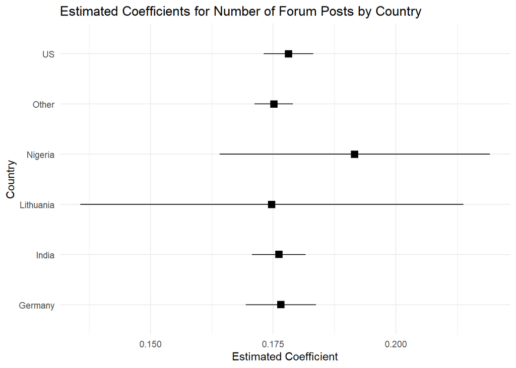

```r
coef_df$lower <- coef_df$coef - 1.96 * coef_df$se
coef_df$upper <- coef_df$coef + 1.96 * coef_df$se

library(ggplot2)
ggplot(coef_df, aes(x = coef, y = rownames(coef_df))) +
  geom_point(shape=15, size=3) +
  geom_linerange(aes(xmin = lower, xmax = upper)) +
  theme_minimal() +
  labs(
    title = "Estimated Coefficients for Number of Forum Posts by Country",
    y = "Country",
    x = "Estimated Coefficient"
  )
```

2. Devise an approach that minimizes the running time of your script. Report the running time of your entire script (running models and estimating coefficients; no need for a new plot). Do not use a different package for the models. Show that the results match those from part a).

```r
cl <- makeCluster(6)
clusterExport(cl, "df_list")
clusterEvalQ(cl, library(lme4))
```

```
[[1]]
[1] "lme4"      "Matrix"    "stats"     "graphics"  "grDevices" "utils"
[7] "datasets"  "methods"   "base"

[[2]]
[1] "lme4"      "Matrix"    "stats"     "graphics"  "grDevices" "utils"
[7] "datasets"  "methods"   "base"

[[3]]
[1] "lme4"      "Matrix"    "stats"     "graphics"  "grDevices" "utils"
[7] "datasets"  "methods"   "base"

[[4]]
[1] "lme4"      "Matrix"    "stats"     "graphics"  "grDevices" "utils"
[7] "datasets"  "methods"   "base"

[[5]]
[1] "lme4"      "Matrix"    "stats"     "graphics"  "grDevices" "utils"
[7] "datasets"  "methods"   "base"

[[6]]
[1] "lme4"      "Matrix"    "stats"     "graphics"  "grDevices" "utils"
[7] "datasets"  "methods"   "base"
```

```r
system.time({
  parallel_results <- parLapply(cl, countries, function(cty) {
    data <- df_list[[cty]]

    t <- system.time({
      model <- glmer(
        completed_course ~ gpa_std + forum_posts_std + quiz_attempts_std + (1 | device_type),
        family = binomial,
        data = data
      )
    })

    list(country = cty, model = model, time = t["elapsed"])
  })
})
```

```
   user  system elapsed
   2.51    1.98 1273.25
```

```r
stopCluster(cl)
```

From the above, the total elapsed time is similar to the runtime of the model with the slowest runtime in part (a).

```r
parallel_time <- sapply(parallel_results, `[[`, "time")

parallel_coef <- sapply(parallel_results, function(x) fixef(x$model)["forum_posts_std"])

coef_df$parallel_time <- parallel_time
coef_df$parallel_coef <- parallel_coef

coef_df[,c("country", "time", "parallel_time", "coef", "parallel_coef")]
```

```
            country    time parallel_time      coef parallel_coef
Germany     Germany  376.17        363.58 0.1765869     0.1765869
India         India  635.67        543.89 0.1761596     0.1761594
Lithuania Lithuania   11.75         18.35 0.1747339     0.1747332
Nigeria     Nigeria   26.08         36.22 0.1916260     0.1916254
Other         Other 1301.98       1269.27 0.1751441     0.1751446
US               US  752.57        682.44 0.1781703     0.1781708
```

From the above, we can see they both produced the same coefficient estimates, while individual model times were similar (in other words, the runtime for each model were the same between serial and parallel, but the total elapsed time differs.)

## Problem 4

For this problem, I referred to the PS4 solutions and followed the approach used there, but using data.table.

```r
library(data.table)
atp_matches <- fread("data/atp_matches_2019.csv")
```

1. How many tournaments took place in 2019?

```r
# initial unique tournaments
tourneys <- unique(atp_matches[, .(tourney_name)])
nrow(tourneys)
```

```
[1] 128
```

```r
# collapse duplicate davis cup entries
tourneys[, tourney_name := sub("Davis.*", "Davis Cup", tourney_name)]

# actual unique tournaments
tourneys <- unique(tourneys)
nrow(tourneys)
```

```
[1] 69
```

69 unique tournaments took place in 2019.

2. Did any player win more than one tournament? If so, how many players won more than one tournament, and how many tournaments did the most winning player(s) win?

```r
# following ps4 solutions:
# arrange by tourney_name, descending match_num
setorder(atp_matches, tourney_name, -match_num)

# group by tourney_name, slice(1), select winner_name
winners <- atp_matches[, .SD[1], by = tourney_name][
  , .(winner_name)
]

# group by winner_name, find count of wins
# filter by wins > 1, descending wins
multiwinners <- winners[
  , .(wins = .N), by = winner_name
][
  wins > 1
][
  order(-wins)
]

multiwinners
```

```
           winner_name  wins
                <char> <int>
 1:       Rafael Nadal     9
 2:     Novak Djokovic     8
 3:     Alex De Minaur     6
 4:      Dominic Thiem     5
 5:      Roger Federer     4
 6:    Daniil Medvedev     4
 7:     Cristian Garin     4
 8:   Denis Shapovalov     4
 9:        Robin Haase     3
10: Stefanos Tsitsipas     3
11:       Nick Kyrgios     2
12:  Matteo Berrettini     2
13:  Diego Schwartzman     2
14:    Karen Khachanov     2
15:       Taylor Fritz     2
16:       Benoit Paire     2
17: Jo-Wilfried Tsonga     2
```

```r
nrow(multiwinners)
```

```
[1] 17
```

17 players won more than one tournament. Rafael Nadal won the most, with 9 tournament wins.

3. Is there any evidence that winners have more aces than losers?

```r
# following ps4 solutions,

# select w_ace, l_ace (remove NA)
aces <- atp_matches[, .(w_ace, l_ace)]
aces <- aces[!is.na(w_ace) & !is.na(l_ace)]

# create variable win_more
aces[, win_more := w_ace > l_ace]

# perform one-sample prop test vs 0.5
test <- prop.test(sum(aces$win_more), nrow(aces), p = 0.5)
test
```

```
    1-sample proportions test with continuity correction

data:  sum(aces$win_more) out of nrow(aces), null probability 0.5
X-squared = 56.749, df = 1, p-value = 4.952e-14
alternative hypothesis: true p is not equal to 0.5
95 percent confidence interval:
 0.5537975 0.5915018
sample estimates:
        p
0.5727543
```

The p value is 4.952e-14 < 0.05, which indicates that winners have more aces than losers.

4. Identify the player(s) with the highest win-rate. (Note that this is NOT asking for the highest number of wins.) Restrict to players with at least 5 matches.

```r
# pivot_longer winners and losers
long <- rbindlist(list(
  atp_matches[, .(player = winner_name, winner = TRUE)],
  atp_matches[, .(player = loser_name, winner = FALSE)]
))

# group by player, find winrate
# filter matches > 5, descending winrate
rates <- long[
  , .(
      matches = .N,
      winrate = mean(winner)
    ),
  by = player
][
  matches > 5
][
  order(-winrate)
]

# slice(1:2)
rates[1:2]
```

```
           player matches   winrate
           <char>   <int>     <num>
1:   Rafael Nadal      69 0.8695652
2: Novak Djokovic      69 0.8405797
```

The player with the highest winrate of 87% is Rafael Nadal.

## Attribution

- e1071 moment function: https://www.rdocumentation.org/packages/e1071/versions/1.7-16/topics/moment
- Forest plot: https://www.khstats.com/blog/forest-plots/